# multinomialTS coding demo

Author

Quinn Asena • Jack Williams • Tony Ives

Published

July 22, 2026

# Introduction

`multinomialTS` fits a state-space model to multinomially distributed ecological time series (community count data such as pollen counts). One of the primary goals is to test multiple hypotheses about the data: which environmental drivers have the strongest effects on which taxa, and are interactions among taxa or abiotic variables driving change in the system? The approach estimates coefficients for taxa interactions and driver–taxa relationships that we don’t get from methods such as ordination or cluster analysis, and we recommend it as complementary to those methods.

This is a short coding demo. A more detailed walkthrough — covering data wrangling and interpretation in depth — is hosted at [multinomialTS-workshop](https://quinnasena.github.io/multinomialTS-workshop/state-space-walkthrough.html), with further resources in the [main workshop repository](https://github.com/QuinnAsena/multinomialTS-workshop).

The talk used Lake Tulane and Sunfish Pond; here we use the package’s built-in **Story Lake** example so you can run every step yourself. We work through the same decisions from the talk:

- **Data decisions** — choose focal taxa / reference group and a prediction resolution
- **Model decisions** — set up working hypotheses (with and without interactions) and fit them
- Interpret and compare the fits

# The data

We will work with the built-in `story` data (Story Lake, IN; (Schlenker et al. 2024)). The taxa have already been wrangled into focal taxa (*Ulmus* / elm, *Fagus grandifolia* / American beech, *Quercus* / oak) plus a `hardwood` group and an `other` reference group. Full details of that wrangling step are in the extended walkthrough. Recall from the talk that a $k$-category multinomial lets us estimate $k-1$ taxa, so the `other` group serves as the reference.

```r
# State variables (Y): pollen counts, wide format
data(story_pollen_wide, package = "multinomialTS")
# Covariate (X): charcoal accumulation
data(story_char_wide, package = "multinomialTS")
```

The state variables ($Y$):

```r
head(story_pollen_wide)
```

```
# A tibble: 6 × 7
# Groups:   age, depth [6]
     age depth other hardwood `Fagus grandifolia` Quercus Ulmus
   <dbl> <dbl> <int>    <int>               <int>   <int> <int>
1 -66.2    0.5   106       60                   8      96     9
2   2.85  32.5   169       26                   8      59    10
3  45.8   64.5   189       27                   8      58     7
4  94.1   96.5   209       17                   2      42    17
5 191.   128.    161       34                  13      55    20
6 203.   132.     88       52                  34      91    19
```

And the covariate ($X$):

```r
head(story_char_wide)
```

```
# A tibble: 6 × 3
    age depth char_acc
  <dbl> <dbl>    <dbl>
1 -66.2   0.5      0
2 -63.4   1.5     15.8
3 -61.4   2.5     40.3
4 -59.8   3.5     21.8
5 -58.5   4.5     37.3
6 -57.2   5.5     29.8
```

I keep the `age` and `depth` columns for now as common variables to join the two tibbles later; they are removed before fitting.

## Plotting the raw data

First, let’s plot the pollen count data. Charcoal is sampled at a finer temporal resolution than the pollen data; this is ideal for the model, which can handle a finer temporal resolution of covariates.

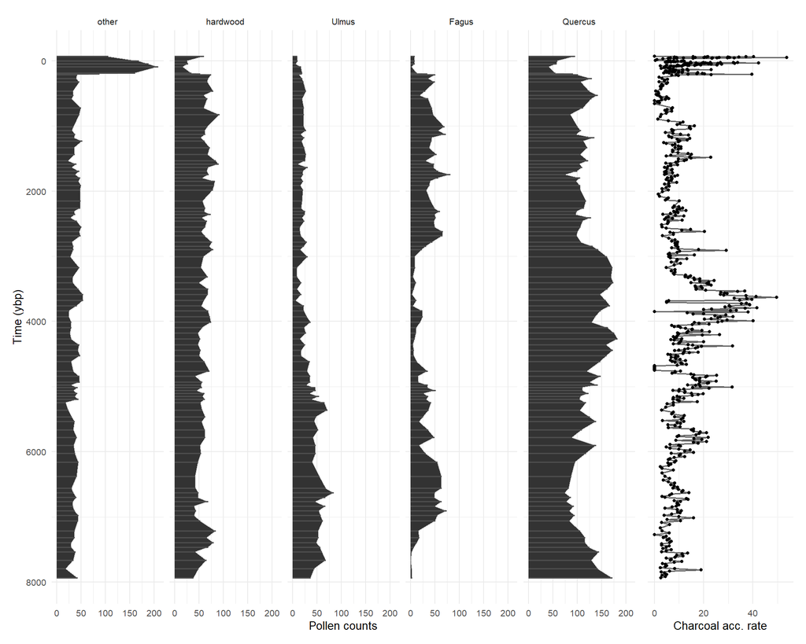

Figure 1: Raw (unbinned) data: pollen counts of the focal taxa and the ‘hardwood’ and ‘other’ groups (left), and the charcoal accumulation rate covariate (right).

```r
# State variables: pivot the aggregated taxa to long format
# (ungroup first: story_pollen_wide is grouped by depth, which select() would otherwise re-add)
species_long <- story_pollen_wide |>
  ungroup() |>
  select(age, other, hardwood, Ulmus, `Fagus grandifolia`, Quercus) |>
  pivot_longer(-age, names_to = "variablename", values_to = "value") |>
  mutate(variablename = factor(
    variablename,
    levels = c("other", "hardwood", "Ulmus", "Fagus grandifolia", "Quercus"),
    labels = c("other", "hardwood", "Ulmus", "Fagus", "Quercus")
  ))

p_species <- ggplot(species_long, aes(x = age, y = value)) +
  geom_area(colour = "grey90") +
  geom_segment(aes(x = age, xend = age, y = 0, yend = value),
               colour = "grey30", linewidth = 0.6) +
  scale_x_reverse(breaks = scales::breaks_pretty(n = 6)) +
  coord_flip() +
  labs(y = "Pollen counts", x = "Time (ybp)") +
  facet_wrap(~variablename, nrow = 1) +
  theme_minimal() +
  theme(text = element_text(size = 10))

# Covariate: clip charcoal to the pollen extent so the age axes align
p_char <- story_char_wide |>
  filter(age <= max(story_pollen_wide$age)) |>
  ggplot(aes(x = age, y = char_acc)) +
  geom_line(colour = "grey40", linewidth = .6) +
  geom_point(size = 1) +
  scale_x_reverse(breaks = scales::breaks_pretty(n = 6)) +
  coord_flip() +
  labs(y = "Charcoal acc. rate", x = NULL) +
  theme_minimal() +
  theme(text = element_text(size = 10),
        axis.text.y = element_blank())

# Combine the species panels and the covariate panel with patchwork
p_species + p_char + plot_layout(widths = c(.8, .2))
```

# State variables $Y$ and the driver

We start by choosing a resolution for the model predictions (e.g., predicting ecological process at 50- or 100-year intervals).

```r
# Time-span divided by number of observations
max_over_n <- max(story_pollen_wide$age) / nrow(story_pollen_wide)
# The range and average of the age differences between successive observations
diff_rng <- range(diff(story_pollen_wide$age))
diff_mean <- mean(diff(story_pollen_wide$age))

cat(
  "\n",
  "Max age / nrow = ", max_over_n, "\n",
  "Range of age differences = ", diff_rng[1], " to ", diff_rng[2], "\n",
  "Mean age difference = ", diff_mean, "\n"
)
```

```
 Max age / nrow =  83.48578
 Range of age differences =  11.459  to  219.725
 Mean age difference =  85.0778
```

Binning at around 50–75 years keeps most of our data in independent bins. We apply the same bin-width to both the state variables and the covariate.

## Joining and binning

Charcoal was sampled at a finer resolution, and to a greater depth than the pollen, so we clip the covariate to the extent of the state variables and join by the common `age` and `depth` variables.

```r
story_join <- story_char_wide |>
  filter(age <= max(story_pollen_wide$age)) |>
  left_join(story_pollen_wide)

# Always double-check dimensions before/after joining!
dim(story_join)
```

```
[1] 646   8
```

```r
# Note that there are now gaps in the pollen data but not the charcoal
head(story_join)
```

```
# A tibble: 6 × 8
    age depth char_acc other hardwood `Fagus grandifolia` Quercus Ulmus
  <dbl> <dbl>    <dbl> <int>    <int>               <int>   <int> <int>
1 -66.2   0.5      0     106       60                   8      96     9
2 -63.4   1.5     15.8    NA       NA                  NA      NA    NA
3 -61.4   2.5     40.3    NA       NA                  NA      NA    NA
4 -59.8   3.5     21.8    NA       NA                  NA      NA    NA
5 -58.5   4.5     37.3    NA       NA                  NA      NA    NA
6 -57.2   5.5     29.8    NA       NA                  NA      NA    NA
```

**Ask me questions!**

What questions do you have so far?

Once we have chosen a prediction resolution, we can bin the data. For covariates we take the *average* value per bin; for pollen counts we take the *sum* (required by the underlying multinomial distribution).

**Note**

We can have a finer temporal resolution of the covariates, but we *cannot* have a finer resolution of the state variables. If your data have a finer resolution of the state variables then it is possible to interpolate the covariate data to match.

```r
bin_width <- 50
bins <- cut(story_join$age,
            breaks = seq(from = min(story_join$age),
                         to = max(story_join$age + bin_width),
                         by = bin_width), include.lowest = TRUE, labels = FALSE)

story_binned <- bind_cols(bins = bins, story_join) |>
  group_by(bins) |>
  summarise(
    age = mean(age, na.rm = TRUE),        # centre of the bin
    char_acc = mean(char_acc, na.rm = TRUE), # mean charcoal accumulation per bin
    other = sum(other, na.rm = TRUE),     # counts are summed
    hardwood = sum(hardwood, na.rm = TRUE),
    `Fagus grandifolia` = sum(`Fagus grandifolia`, na.rm = TRUE),
    Ulmus = sum(Ulmus, na.rm = TRUE),
    Quercus = sum(Quercus, na.rm = TRUE)
  ) |>
  arrange(desc(age))
# Note: gaps in the pollen data are now filled with 0's, not NA
```

**Important**

We want the model to run from the past to the present, and the model runs from the top of the matrix to the bottom. So we want to make sure that the top row of the data is the *oldest* date. Palaeo-data are usually ordered from the top of the core to the bottom (present to past), so we `arrange(desc(age))`.

## Building the model matrices

`multinomialTS` requires two matrices: a site-by-species matrix $Y$, and a covariate matrix $X$. $X$ variables may be of different types but should be scaled relative to each other.

```r
story_pollen_matrix <- story_binned |>
  select(other, hardwood, Ulmus, `Fagus grandifolia`, Quercus) |>
  rename("Fagus" = "Fagus grandifolia") |>
  as.matrix()
# Empty (gap) rows are set to NA so they are not treated as zero-count observations
story_pollen_matrix[which(rowSums(story_pollen_matrix) == 0), ] <- NA
head(story_pollen_matrix)
```

```
     other hardwood Ulmus Fagus Quercus
[1,]    43       39    37     3     172
[2,]    NA       NA    NA    NA      NA
[3,]    19       49    45     2     142
[4,]    NA       NA    NA    NA      NA
[5,]    NA       NA    NA    NA      NA
[6,]    34       65    68     1     129
```

```r
story_char_matrix_scaled <- story_binned |>
  select(char_acc) |>
  as.matrix() |>
  scale()
head(story_char_matrix_scaled)
```

```
       char_acc
[1,] -0.9826414
[2,] -0.8978991
[3,]  0.1548837
[4,] -0.8894600
[5,] -0.7078643
[6,] -0.2731469
```

# Fitting `multinomialTS`

We now have a temporal resolution of 50-year bins, a site-by-species matrix $Y$, and a binned and scaled covariate matrix $X$.

## Finding initial conditions with `mnGLMM()`

`mnTS()` estimates biotic interactions ($C$ matrix), taxa-driver relationships ($B$ matrix), and cross-correlated error ($V$ matrix), but it needs starting values for $B$, $B_0$ (intercept), and $V$. We get those from `mnGLMM()`, which returns estimates for $B$ and $V$ (not $C$) and assumes no time gaps in the data.

For `mnGLMM()` we need:

- A vector that indicates the row indices where there are state variable observations: `sample_idx`
- An integer number of covariates (+ 1 for `mnGLMM()`): `p`
- An integer of the number of state variables: `n`
- A matrix of starting values for $B$: `B.start.glmm`
- A matrix of $B$ parameters to estimate: `B.fixed.glmm`
- A matrix of $V$ parameters to estimate: `V.fixed.glmm`

**Tip**

Arguments for *starting* values are suffixed `.start`; arguments for the parameters to be *estimated* are suffixed `.fixed`.

```r
# Row indices of bins that contain pollen observations (exclude empty/gap bins)
sample_idx <- which(rowSums(story_pollen_matrix) != 0)
```

```r
p <- ncol(story_char_matrix_scaled) + 1 # number of covariates + intercept
n <- ncol(story_pollen_matrix)          # number of taxa
V.fixed.glmm <- diag(n)
diag(V.fixed.glmm) <- NA
V.fixed.glmm[1] <- 1
B.fixed.glmm <- matrix(c(rep(0, p), rep(NA, (n - 1) * p)), p, n) # reference taxa [,1] set to 0
B.start.glmm <- matrix(c(rep(0, p), rep(.01, (n - 1) * p)), p, n)
```

`mnGLMM()` does not handle gaps, so we index the matrices by `sample_idx`. The fit below is precomputed (loaded from `./outputs/`) so the document renders quickly; set `eval: true` to run it live.

```r
start_time <- Sys.time()
glmm_mod <- mnGLMM(Y = story_pollen_matrix[sample_idx, ],
                   X = story_char_matrix_scaled[sample_idx, , drop = FALSE],
                   B.start = B.start.glmm,
                   B.fixed = B.fixed.glmm,
                   V.fixed = V.fixed.glmm)
end_time <- Sys.time()
end_time - start_time
saveRDS(glmm_mod, "./outputs/glmm_mod.rds")
```

```r
glmm_mod <- readRDS("./outputs/glmm_mod.rds")
summary(glmm_mod)
```

```
Call: mnGLMM with Tmax =  93  n =  5

logLik = 506.1927,  AIC = -984.3855 [df = 14]

dispersion parameter =  1

Fitted Coefficients with approximate se
                           Coef.         se          t            P
(intercept).hardwood  0.32520811 0.08449716  3.8487458 1.187241e-04
char_acc.hardwood    -0.15611487 0.08828463 -1.7683131 7.700857e-02
(intercept).Ulmus    -0.31412638 0.11063702 -2.8392520 4.521943e-03
char_acc.Ulmus       -0.27877600 0.10904256 -2.5565798 1.057068e-02
(intercept).Fagus    -0.26463046 0.11061642 -2.3923254 1.674199e-02
char_acc.Fagus       -0.44518124 0.11465599 -3.8827559 1.032792e-04
(intercept).Quercus   0.99820811 0.08800698 11.3423747 8.091837e-30
char_acc.Quercus     -0.06223392 0.09098400 -0.6840095 4.939692e-01


Overall model

B =
     [,1]       [,2]       [,3]       [,4]        [,5]
[1,]    0  0.3252081 -0.3141264 -0.2646305  0.99820811
[2,]    0 -0.1561149 -0.2787760 -0.4451812 -0.06223392

sigma =  1.055386

V =
     [,1]        [,2]      [,3]      [,4]       [,5]
[1,]    1 0.000000000 0.0000000 0.0000000 0.00000000
[2,]    0 0.004430417 0.0000000 0.0000000 0.00000000
[3,]    0 0.000000000 0.3021317 0.0000000 0.00000000
[4,]    0 0.000000000 0.0000000 0.3045218 0.00000000
[5,]    0 0.000000000 0.0000000 0.0000000 0.07575791
```

## Setting up parameters for `mnTS()`

We use the `mnGLMM()` output as starting values for $B_0$, $B$, and $V$. `mnGLMM()` does not estimate $C$, so we seed $C$ with values close to zero and let `mnTS()` do the rest.

```r
B0.start.mnTS <- glmm_mod$B[1, , drop = FALSE] # intercept
B.start.mnTS  <- glmm_mod$B[2, , drop = FALSE] # covariate; add rows for more covariates

sigma.start.mnTS <- glmm_mod$sigma

V.fixed.mnTS <- matrix(NA, n, n)
V.fixed.mnTS[1] <- 1
V.start.mnTS <- glmm_mod$V

B.fixed.mnTS <- matrix(NA, p - 1, n)
B.fixed.mnTS[, 1] <- 0
B0.fixed.mnTS <- matrix(c(0, rep(NA, n - 1)), nrow = 1, ncol = n)

# C without interactions: diagonal = self-regulation (estimated); off-diagonal = 0 (not estimated)
C.start.mnTS <- .5 * diag(n)
C.fixed.mnTS <- C.start.mnTS
C.fixed.mnTS[C.fixed.mnTS != 0] <- NA

# C with an interaction between Fagus and Quercus
C.start.int.mnTS <- .5 * diag(n)
C.start.int.mnTS[5, 4] <- .001 # effect of Fagus (col 4) on Quercus (row 5)
C.start.int.mnTS[4, 5] <- .001 # effect of Quercus (col 5) on Fagus (row 4)
C.fixed.int.mnTS <- C.start.int.mnTS
C.fixed.int.mnTS[C.fixed.int.mnTS != 0] <- NA
```

## Fitting `mnTS()`

Unlike `mnGLMM()`, `mnTS()` *does* handle gaps in the state variables where there are data in the covariate matrix. We fit the model twice, with each fit standing in for a working hypothesis: a null with no interactions versus one where *Fagus* and *Quercus* interact. Both fits are precomputed; set `eval: true` to run them live.

**Without interactions**

```r
mnTS_mod <- mnTS(Y = story_pollen_matrix[sample_idx, ],
                 X = story_char_matrix_scaled, Tsample = sample_idx,
                 B0.start = B0.start.mnTS, B0.fixed = B0.fixed.mnTS,
                 B.start = B.start.mnTS, B.fixed = B.fixed.mnTS,
                 C.start = C.start.mnTS, C.fixed = C.fixed.mnTS,
                 V.start = V.start.mnTS, V.fixed = V.fixed.mnTS,
                 dispersion.fixed = 1, maxit.optim = 1e+6)
# maxit.optim: max optimiser iterations before stopping; increase if the model needs more time
saveRDS(mnTS_mod, "./outputs/mnTS_mod.rds")
```

```r
mnTS_mod <- readRDS("./outputs/mnTS_mod.rds")
```

**With interactions**

```r
mnTS_mod_int <- mnTS(Y = story_pollen_matrix[sample_idx, ],
                     X = story_char_matrix_scaled, Tsample = sample_idx,
                     B0.start = mnTS_mod$B0, B0.fixed = B0.fixed.mnTS,
                     B.start = mnTS_mod$B, B.fixed = B.fixed.mnTS,
                     C.start = mnTS_mod$C, C.fixed = C.fixed.int.mnTS,
                     V.start = mnTS_mod$V, V.fixed = V.fixed.mnTS,
                     dispersion.fixed = 1, maxit.optim = 1e+6)
saveRDS(mnTS_mod_int, "./outputs/mnTS_mod_int.rds")
```

```r
mnTS_mod_int <- readRDS("./outputs/mnTS_mod_int.rds")
```

# Interpreting the output

`coef()` and `summary()` show the model output. The `B` coefficients are the driver effects and the `C` coefficients the taxa interactions — the same matrices shown as heatmaps in the talk’s results slides.

**Without interactions**

```r
coef(mnTS_mod)
```

```
                           Coef.          se          t             P
hardwood              0.41488472 0.130193031   3.186689  1.439113e-03
Ulmus                -1.06503437 0.279391571  -3.811977  1.378595e-04
Fagus                -0.50134684 0.335198066  -1.495673  1.347388e-01
Quercus               1.11981238 0.147451169   7.594463  3.090726e-14
sp.other.other        0.81268011 0.068275092  11.903025  1.141340e-32
sp.hardwood.hardwood  0.42512861 0.298181430   1.425738  1.539440e-01
sp.Ulmus.Ulmus        0.99736670 0.004246981 234.841321  0.000000e+00
sp.Fagus.Fagus        0.92145228 0.031233873  29.501698 2.738150e-191
sp.Quercus.Quercus    0.86736113 0.062966764  13.774904  3.608633e-43
char_acc.hardwood    -0.08181535 0.045248405  -1.808138  7.058505e-02
char_acc.Ulmus       -0.12986090 0.055705655  -2.331198  1.974293e-02
char_acc.Fagus       -0.11385375 0.073408033  -1.550971  1.209086e-01
char_acc.Quercus     -0.09087417 0.043940745  -2.068107  3.862995e-02
```

**With interactions**

```r
coef(mnTS_mod_int)
```

```
                           Coef.         se         t            P
hardwood              0.70701092 0.36912747  1.915357 5.544698e-02
Ulmus                -0.47383592 0.32512039 -1.457417 1.450014e-01
Fagus                -0.82708529 0.34388320 -2.405134 1.616652e-02
Quercus               1.42508734 0.31361083  4.544127 5.516348e-06
sp.other.other        0.88903728 0.01737083 51.179889 0.000000e+00
sp.hardwood.hardwood  0.96247827 0.01603352 60.029117 0.000000e+00
sp.Ulmus.Ulmus        0.94801846 0.02426052 39.076586 0.000000e+00
sp.Fagus.Fagus        0.80038451 0.05099097 15.696592 1.595888e-55
sp.Quercus.Fagus      0.06547106 0.01264887  5.176042 2.266429e-07
sp.Fagus.Quercus     -0.10205881 0.04126391 -2.473319 1.338645e-02
sp.Quercus.Quercus    0.99635812 0.01833404 54.344718 0.000000e+00
char_acc.hardwood    -0.15462592 0.02565652 -6.026769 1.672696e-09
char_acc.Ulmus       -0.14556882 0.04356441 -3.341462 8.333850e-04
char_acc.Fagus       -0.21981877 0.05499133 -3.997335 6.405959e-05
char_acc.Quercus     -0.17458198 0.02669360 -6.540219 6.142871e-11
```

We have found that bootstrapping provides better estimates of standard errors (and P-values). The `boot()` function bootstraps the model but can take a long time; we don’t do it here, but we strongly recommend bootstrapping your final models — see the [full walkthrough](https://quinnasena.github.io/multinomialTS-workshop/state-space-walkthrough.html).

# References

Schlenker, Nora, Jonathan Johnson, Tessa Ray-Cozzens, Vania Stefanova, David M. Nelson, Bryan N. Shuman, and John W. Williams. 2024. “Interacting Effects of Fire and Hydroclimate on Oak and Beech Community Prevalence in the Southern Great Lakes Region.” *Journal of Ecology* 112 (5): 1101–22. https://doi.org/10.1111/1365-2745.14289.